title: “Final Project” output: html_document —

# Introduction

https://www.bls.gov/brs/data/tables/

My data was retrieved from the Bureau of Labor Statistics at the URL above. It’s a Business Response (BRS) about the impact of coronavirus on business within the US and was conducted from July 20, 2020 - September 30, 2020. Responses were requested via email and printletters and collected online. The purpose of the survey was to help understand how businesses have responded to the pandemic. I chose this dataset because I’ve recently been bombarded with commercials and advertisements about what lsrge businesses have been making to procedure in order adjust to the “new normal” and to help accomodate their employees but I was interested in whether or not these changes were real and whether they were representative of a general trend. The main question I wanted to answer was whether the likelihood of a business accommodating its employees is related to politics - more specifically whether employee accomodations are influenced by the political party of the state.

## Required Packages

```r
library(readr)
library(gt)
library(tidyverse)
library(dplyr)
```

# Cleaning

After looking at the data key I was able to identify a few survey questions that were relevant to the questions I wanted to answer so I renamed these variables and merged the datasets which they came from using “State” as it was the one column each set had in common.

## Variable Creation

```r
merged <- merge(Demand_closure_state, Kept_paying_state, by = "Statec")
merged <- merge(merged, Payed_health_insureance_state, by = "Statec")
merged <- merge(merged, Inc_paid_leave_state, by = "Statec")
merged <- merge(merged, Business_state, by = "Statec")
merged <- merge(merged, Telework_state, by = "Statec")
merged <- merge(merged, Gotgov_grant_state, by = "Statec")
merged <- select(merged, contains("c"))
merged <- rename(merged, State = Statec)
```

It is worth noting that while renaming I had to change “State” to “Statec” so that I could select for all the rows I wanted using a common character that was absent elsewhere in the code; . Since I performed multiple merges I also checked the dimensions after each time.

```r
merged$closure.state <- as.factor(ifelse(merged$percent.gov.closure > 18.74, "Yes", "No"))
merged$health.insurance.state <- as.factor(ifelse(merged$percent.payed.insurance > 41.86, "Yes", "No"))
merged$no.tele.state <- as.factor(ifelse(merged$percent.no.tele > 52.25, "Yes", "No"))
merged$paid.leave.state <- as.factor(ifelse(merged$percent.inc.leave > 13.85, "Yes", "No"))
merged$telework.state <- as.factor(ifelse(merged$percent.w.inc.tele > 30.89, "Yes", "No"))
merged$payed.nowork.state <- as.factor(ifelse(merged$percent.payed.nowork > 51.25, "Yes", "No"))
merged$gov.grant.state <- as.factor(ifelse(merged$percent.gotgov.grant > 62.13, "Yes", "No"))
dim(merged)
```

```
## [1] 53 49
```

The next step was creating a variable for Political party, a variable for State symbol (for the plots later on) and ordering the rows of my dataframe in a way that made the most sense to me. In the process of doing this I was also able to get rid of one of the rows which wasn’t relevant to my questions

```r
merged <- merged[c(46, 1:39, 41:45, 47:53),]
```

# Visualization

I decided to make two different datasets from my original which I would use to make my plots and charts; one based on the government closure flag and one based on the government grant flag

```r
Closure <- filter(merged, closure.state == "Yes")
Govgrant <- filter(merged, gov.grant.state == "Yes")
```

## Plots

### Plot 1 - Effect of Political Party on Telework Offered Post-Closure

For my first plot I looked at percentage of establishments with no telework offered grouped by political party and state

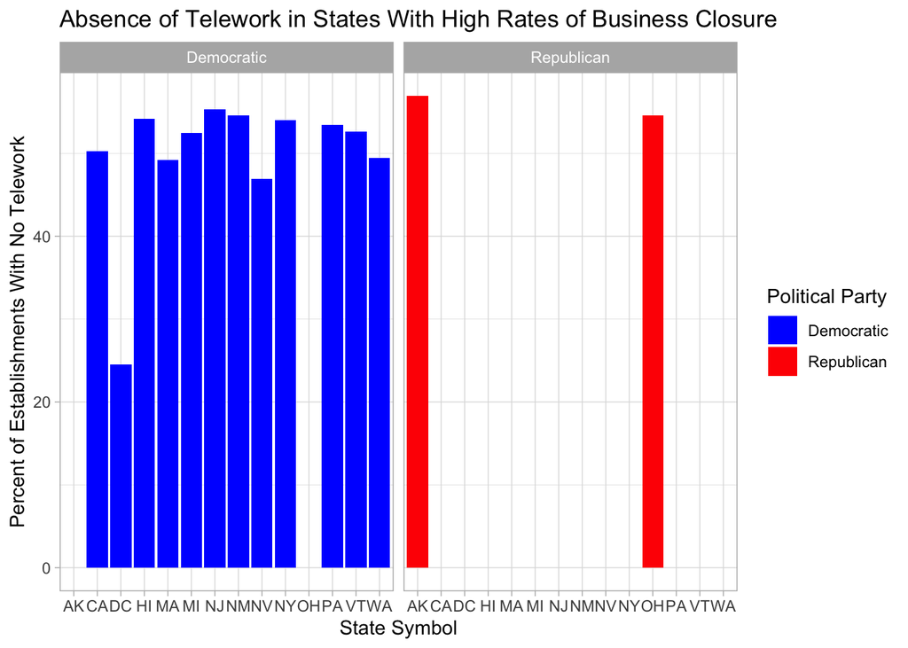

```r
ggplot(data = Closure, aes(x = State_Symbol, y = percent.no.tele, fill = Poliparty)) +
  geom_col() +
  scale_fill_manual(values = c("blue", "red")) +
  xlab("State Symbol") +
  ylab("Percent of Establishments With No Telework") +
  ggtitle("Absence of Telework in States With High Rates of Business Closure") +
  guides(fill = guide_legend(title = "Political Party")) +
  theme_light() +
  facet_wrap(~ Poliparty)
```

For my next 3 plots I looked at the percentage of establishments with that put their grant money towards certain employee benefits

### Plot 2 - Effect of Political Party on Allocation of Grant Funds A

[figure not shown]

```r
ggplot(data = Govgrant, aes(x = State_Symbol, y = percent.payed.nowork, fill = Poliparty)) +
  geom_col() +
  scale_fill_manual(values = c("blue", "red")) +
  xlab("State Symbol") +
  ylab("Percent of Establishments That Continued to Pay Employees While Not Working") +
  ggtitle("Non-worked Pay in States With High Rates of Business CLosure") +
  guides(fill = guide_legend(title = "Political Party")) +
  facet_wrap(~ Poliparty) +
  theme_light()
```

### Plot 3 - Effect of Political Party on Allocation of Grant Funds B

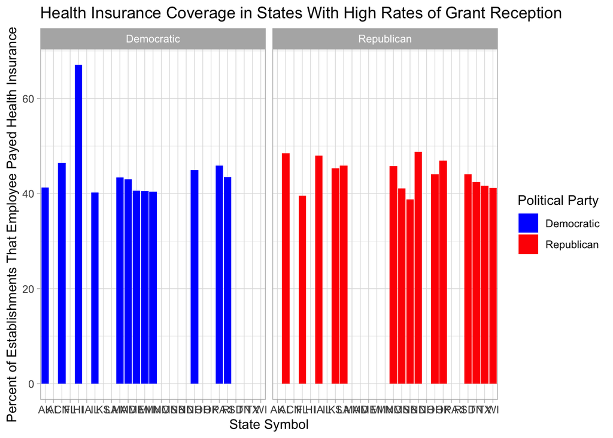

```r
ggplot(data = Govgrant, aes(x = State_Symbol, y = percent.payed.insurance, fill = Poliparty)) +
  geom_col() +
  scale_fill_manual(values = c("blue", "red")) +
  xlab("State Symbol") +
  ylab("Percent of Establishments That Employee Payed Health Insurance") +
  ggtitle("Health Insurance Coverage in States With High Rates of Grant Reception")  +
  guides(fill = guide_legend(title = "Political Party")) +
  facet_wrap(~ Poliparty) +
  theme_light()
```

### Plot 4 - Effect of Political Party on Allocatino of Grant Funds C

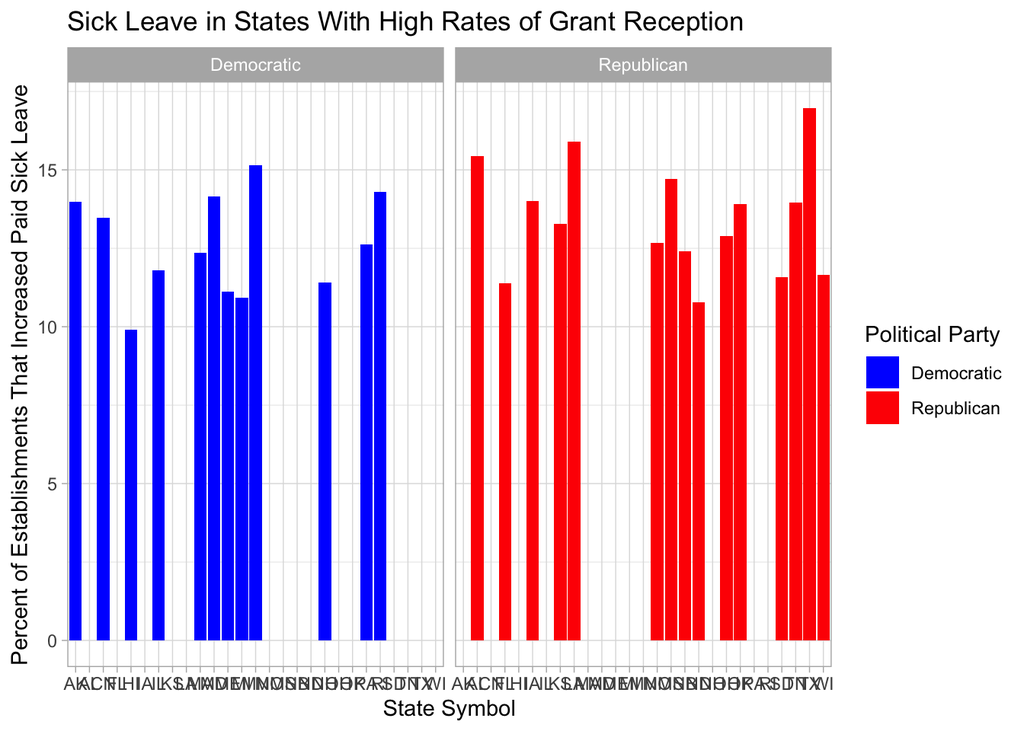

```r
ggplot(data = Govgrant, aes(x = State_Symbol, y = percent.inc.leave, fill = Poliparty)) +
  geom_col() +
  scale_fill_manual(values = c("blue", "red")) +
  xlab("State Symbol") +
  ylab("Percent of Establishments That Increased Paid Sick Leave") +
  ggtitle("Sick Leave in States With High Rates of Grant Reception") +
  guides(fill = guide_legend(title = "Political Party")) +
  facet_wrap(~ Poliparty) +
  theme_light()
```

## Tables

I intended for my tables to provide a more detailed look at the differences between states as it related to their political party. In order to do that I created a few more new variables so that I could compare averages in my variables of interest. I wanted to see whether states that were high in government closure were also high in telework and whether states where many businesses received covid-related grants also put those grants towards some employee benefits.

I wanted to see whether states that were high in government closure were also high in telework and whether states where many businesses received covid-related grants also put those grants towards some employee benefits. I was also interested in whether these measures changed as a function of political party

### Table 1 - Closure Table

Telework Accomodations In Response to Covid Closures

Percent of Establishments

| State_Symbol | Increased Telework (Democratic) | Increased Telework (Republican) | Percentage by State Increased Telework | Percentage by State No Telework Available | No Telework Available (Democratic) | No Telework Available (Republican) |  |  |
| --- | --- | --- | --- | --- | --- | --- | --- | --- |
| Republican |  |  |  |  |  |  |  |  |
| AK | 33.66917 | 29.75 | 28.81 | 56.95 |  |  | 49.7575 | 55.765 |
| OH | 33.66917 | 29.75 | 30.69 | 54.58 | 49.7575 | 55.765 |  |  |
| Democratic |  |  |  |  |  |  |  |  |
| CA | 33.66917 | 29.75 | 33.64 | 50.30 | 49.7575 | 55.765 |  |  |
| DC | 33.66917 | 29.75 | 56.98 | 24.52 | 49.7575 | 55.765 |  |  |
| HI | 33.66917 | 29.75 | 31.31 | 54.17 | 49.7575 | 55.765 |  |  |
| MA | 33.66917 | 29.75 | 35.40 | 49.22 | 49.7575 | 55.765 |  |  |
| MI | 33.66917 | 29.75 | 31.64 | 52.50 | 49.7575 | 55.765 |  |  |
| NV | 33.66917 | 29.75 | 31.83 | 46.91 | 49.7575 | 55.765 |  |  |
| NJ | 33.66917 | 29.75 | 30.20 | 55.31 | 49.7575 | 55.765 |  |  |
| NM | 33.66917 | 29.75 | 28.07 | 54.59 | 49.7575 | 55.765 |  |  |
| NY | 33.66917 | 29.75 | 30.90 | 54.05 | 49.7575 | 55.765 |  |  |
| PA | 33.66917 | 29.75 | 30.90 | 53.47 | 49.7575 | 55.765 |  |  |
| VT | 33.66917 | 29.75 | 30.16 | 52.64 | 49.7575 | 55.765 |  |  |
| WA | 33.66917 | 29.75 | 33.00 | 49.41 | 49.7575 | 55.765 |  |  |

### Table 3 - Covid-Related Grant Table A

Employee Income Accomodations In Response to covid Grant

Percent of Establishments

| State_Symbol | Payed Employee Healh Insurance (Democratic) | Payed Employee Health Insurance (Republican) | Percentage by State Payed Employee Health Insurance | Percentage by State Payed Employees Nonworked Time | Payed Employees Nonworked Time (Democratic) | Payed Employees Nonworked Time (Republican) |  |  |
| --- | --- | --- | --- | --- | --- | --- | --- | --- |
| Republican |  |  |  |  |  |  |  |  |
| AL | 44.78333 | 44.132 | 48.50 | 64.26 |  |  | 47.35833 | 58.34267 |
| FL | 44.78333 | 44.132 | 39.53 | 62.44 | 47.35833 | 58.34267 |  |  |
| IA | 44.78333 | 44.132 | 47.99 | 54.40 | 47.35833 | 58.34267 |  |  |
| KS | 44.78333 | 44.132 | 45.31 | 61.09 | 47.35833 | 58.34267 |  |  |
| LA | 44.78333 | 44.132 | 45.90 | 58.99 | 47.35833 | 58.34267 |  |  |
| MS | 44.78333 | 44.132 | 41.06 | 65.79 | 47.35833 | 58.34267 |  |  |
| MO | 44.78333 | 44.132 | 45.76 | 56.51 | 47.35833 | 58.34267 |  |  |
| NB | 44.78333 | 44.132 | 38.78 | 60.42 | 47.35833 | 58.34267 |  |  |
| ND | 44.78333 | 44.132 | 48.80 | 55.63 | 47.35833 | 58.34267 |  |  |
| OH | 44.78333 | 44.132 | 44.08 | 47.59 | 47.35833 | 58.34267 |  |  |
| OK | 44.78333 | 44.132 | 46.92 | 62.85 | 47.35833 | 58.34267 |  |  |
| SD | 44.78333 | 44.132 | 44.02 | 60.79 | 47.35833 | 58.34267 |  |  |
| TN | 44.78333 | 44.132 | 42.44 | 55.60 | 47.35833 | 58.34267 |  |  |
| TX | 44.78333 | 44.132 | 41.70 | 60.93 | 47.35833 | 58.34267 |  |  |
| WI | 44.78333 | 44.132 | 41.19 | 47.85 | 47.35833 | 58.34267 |  |  |
| Democratic |  |  |  |  |  |  |  |  |
| AK | 44.78333 | 44.132 | 41.31 | 53.64 | 47.35833 | 58.34267 |  |  |
| CN | 44.78333 | 44.132 | 46.45 | 48.13 | 47.35833 | 58.34267 |  |  |
| HI | 44.78333 | 44.132 | 67.11 | 44.27 | 47.35833 | 58.34267 |  |  |
| IL | 44.78333 | 44.132 | 40.25 | 53.05 | 47.35833 | 58.34267 |  |  |
| ME | 44.78333 | 44.132 | 40.57 | 46.77 | 47.35833 | 58.34267 |  |  |
| MD | 44.78333 | 44.132 | 42.97 | 53.07 | 47.35833 | 58.34267 |  |  |
| MA | 44.78333 | 44.132 | 43.39 | 46.98 | 47.35833 | 58.34267 |  |  |
| MI | 44.78333 | 44.132 | 40.54 | 40.81 | 47.35833 | 58.34267 |  |  |
| MN | 44.78333 | 44.132 | 40.45 | 45.91 | 47.35833 | 58.34267 |  |  |
| NH | 44.78333 | 44.132 | 44.97 | 47.54 | 47.35833 | 58.34267 |  |  |
| PA | 44.78333 | 44.132 | 45.93 | 44.53 | 47.35833 | 58.34267 |  |  |
| RI | 44.78333 | 44.132 | 43.46 | 43.60 | 47.35833 | 58.34267 |  |  |

### Table 3 - Covid-Related Grant Table B

```r
Govgrant %>%
  group_by(Poliparty) %>%
  select(Poliparty, State_Symbol, Avg.inc.leave.Dem, Avg.inc.leave.Rep, percent.inc.leave,
         percent.payed.nowork, Avg.payed.no.work.Dem, Avg.payed.no.work.Rep) %>%
  gt(rowname_col = "State Symbol") %>%
  tab_header(title = "Employee Accomodations In Response to covid Grant",
             subtitle = "Percent of Establishments") %>%
  tab_spanner(label = "Percentage by State",
              columns = vars(percent.inc.leave, percent.payed.nowork)) %>%
  cols_label(Avg.inc.leave.Dem = "Increased Paid Sick Leave (Democratic)",
             Avg.inc.leave.Rep = "Increased Paid Sick Leave (Republican)",
             percent.inc.leave = "Increased Paid Sick Leave",
             percent.payed.nowork = "Payed Employees Nonworked Time",
             Avg.payed.no.work.Dem = "Payed Employees Nonworked Time (Democratic)",
             Avg.payed.no.work.Rep = "Payed Employees Nonworked Time (Republican)")
```

Employee Accomodations In Response to covid Grant

Percent of Establishments

| State_Symbol | Increased Paid Sick Leave (Democratic) | Increased Paid Sick Leave (Republican) | Percentage by State Increased Paid Sick Leave | Percentage by State Payed Employees Nonworked Time | Payed Employees Nonworked Time (Democratic) | Payed Employees Nonworked Time (Republican) |  |  |
| --- | --- | --- | --- | --- | --- | --- | --- | --- |
| Republican |  |  |  |  |  |  |  |  |
| AL | 12.59583 | 13.43667 | 15.43 | 64.26 |  |  | 47.35833 | 58.34267 |
| FL | 12.59583 | 13.43667 | 11.39 | 62.44 | 47.35833 | 58.34267 |  |  |
| IA | 12.59583 | 13.43667 | 14.01 | 54.40 | 47.35833 | 58.34267 |  |  |
| KS | 12.59583 | 13.43667 | 13.28 | 61.09 | 47.35833 | 58.34267 |  |  |
| LA | 12.59583 | 13.43667 | 15.89 | 58.99 | 47.35833 | 58.34267 |  |  |
| MS | 12.59583 | 13.43667 | 14.70 | 65.79 | 47.35833 | 58.34267 |  |  |
| MO | 12.59583 | 13.43667 | 12.67 | 56.51 | 47.35833 | 58.34267 |  |  |
| NB | 12.59583 | 13.43667 | 12.41 | 60.42 | 47.35833 | 58.34267 |  |  |
| ND | 12.59583 | 13.43667 | 10.79 | 55.63 | 47.35833 | 58.34267 |  |  |
| OH | 12.59583 | 13.43667 | 12.89 | 47.59 | 47.35833 | 58.34267 |  |  |
| OK | 12.59583 | 13.43667 | 13.92 | 62.85 | 47.35833 | 58.34267 |  |  |
| SD | 12.59583 | 13.43667 | 11.58 | 60.79 | 47.35833 | 58.34267 |  |  |
| TN | 12.59583 | 13.43667 | 13.97 | 55.60 | 47.35833 | 58.34267 |  |  |
| TX | 12.59583 | 13.43667 | 16.97 | 60.93 | 47.35833 | 58.34267 |  |  |
| WI | 12.59583 | 13.43667 | 11.65 | 47.85 | 47.35833 | 58.34267 |  |  |
| Democratic |  |  |  |  |  |  |  |  |
| AK | 12.59583 | 13.43667 | 13.99 | 53.64 | 47.35833 | 58.34267 |  |  |
| CN | 12.59583 | 13.43667 | 13.48 | 48.13 | 47.35833 | 58.34267 |  |  |
| HI | 12.59583 | 13.43667 | 9.90 | 44.27 | 47.35833 | 58.34267 |  |  |
| IL | 12.59583 | 13.43667 | 11.80 | 53.05 | 47.35833 | 58.34267 |  |  |
| ME | 12.59583 | 13.43667 | 11.11 | 46.77 | 47.35833 | 58.34267 |  |  |
| MD | 12.59583 | 13.43667 | 14.14 | 53.07 | 47.35833 | 58.34267 |  |  |
| MA | 12.59583 | 13.43667 | 12.36 | 46.98 | 47.35833 | 58.34267 |  |  |
| MI | 12.59583 | 13.43667 | 10.92 | 40.81 | 47.35833 | 58.34267 |  |  |
| MN | 12.59583 | 13.43667 | 15.14 | 45.91 | 47.35833 | 58.34267 |  |  |
| NH | 12.59583 | 13.43667 | 11.40 | 47.54 | 47.35833 | 58.34267 |  |  |
| PA | 12.59583 | 13.43667 | 12.62 | 44.53 | 47.35833 | 58.34267 |  |  |
| RI | 12.59583 | 13.43667 | 14.29 | 43.60 | 47.35833 | 58.34267 |  |  |